# Practical 3 — Superstore discounts and profit

Association, group comparisons and business interpretation · 307312 Applied Statistics

- Companion to association and group comparisons in Part 2.
- Complete Practicals 1 and 2.
- Allow two sessions of about 40–50 minutes.

**By the end, you should be able to:**

- Compare sales, profit and weighted margins.
- Summarize groups using distributions as well as totals.
- Use scatterplots and correlations with the correct observational unit.
- Distinguish a useful business lead from a causal conclusion.

## 1. The commercial manager’s question

> Which product groups deserve a discount and profitability review?
- **Source:** Tableau’s fictitious Superstore, downloaded 6 November 2026.
- **Scope:** US orders placed in 2023–2025.
- **Line analysis:** 6,682 product lines for categories and discount bands.
- **Order analysis:** 3,322 orders for basket sales and profit.
- **Units:** sales and profit in dollars; discount as a fraction.
- **Limit:** discount decisions were not randomized; product mix and other factors differ across groups.

## 2. Import and construct useful variables

```r
source("lessons/_includes/course-tools.R")
lines <- read.csv("data/business/superstore-lines.csv",
                  stringsAsFactors = FALSE, colClasses = c(postal_code = "character"))
orders <- make_orders(lines)
lines <- lines %>% mutate(
  line_margin_pct = 100 * profit / sales,
  loss_line = profit < 0,
  discount_band = cut(discount, breaks = c(-Inf, 0, .2, Inf),
    labels = c("None", "Above 0 to 20%", "Above 20%"), ordered_result = TRUE))
stopifnot(!anyNA(lines$discount_band), all(lines$sales > 0))
```

- `data/business/superstore-lines.csv`; guide: `data/business/README.md`.
- A 20% discount belongs to the middle band; zero belongs to **None**.
- These bands are analyst-defined categories, not source classifications.
- A line’s margin is profit divided by its recorded sales.
- We do not construct a discount-adjusted revenue or refund measure from undocumented accounting assumptions.

## 3. Compare categories fairly

```r
category_results <- lines %>% group_by(category) %>%
  summarise(line_count = n(), total_sales = sum(sales), total_profit = sum(profit),
            median_line_profit = median(profit), loss_line_pct = 100 * mean(loss_line),
            .groups = "drop") %>%
  mutate(overall_margin_pct = 100 * total_profit / total_sales)
knitr::kable(category_results, digits = 2)
```

| category | line_count | total_sales | total_profit | median_line_profit | loss_line_pct | overall_margin_pct |
| --- | --- | --- | --- | --- | --- | --- |
| Furniture | 1435 | 526612.5 | 15432.88 | 8.64 | 33.38 | 2.93 |
| Office Supplies | 4024 | 472949.9 | 82754.18 | 6.94 | 14.66 | 17.50 |
| Technology | 1223 | 564423.2 | 94770.69 | 26.59 | 14.88 | 16.79 |

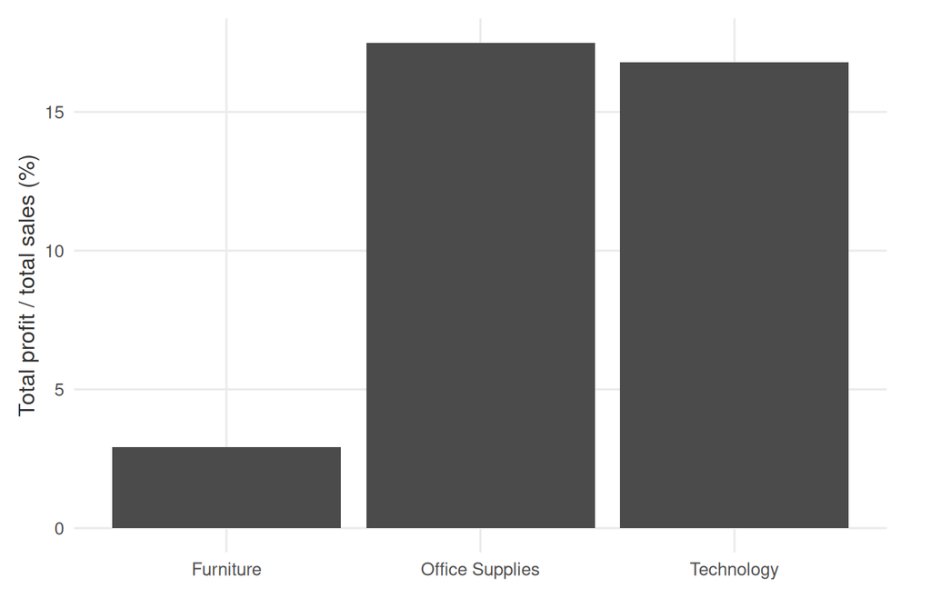

```r
ggplot(category_results, aes(category, overall_margin_pct)) +
  geom_col(fill = petra_ink) +
  labs(x = NULL, y = "Total profit / total sales (%)")
```

- Furniture has substantial sales but a much thinner overall margin in this extract.
- Category totals describe business contribution; median line profit describes a typical line.
- The loss-line rate uses lines as its denominator.
- A category can contain both profitable and loss-making subcategories.

### Why an average of percentages can mislead

```r
margin_comparison <- lines %>% group_by(category) %>%
  summarise(equal_line_mean_margin_pct = mean(line_margin_pct),
            sales_weighted_margin_pct = 100 * sum(profit) / sum(sales), .groups = "drop")
knitr::kable(margin_comparison, digits = 2)
```

| category | equal_line_mean_margin_pct | sales_weighted_margin_pct |
| --- | --- | --- |
| Furniture | 3.89 | 2.93 |
| Office Supplies | 14.30 | 17.50 |
| Technology | 15.31 | 16.79 |

- The first gives every line equal weight.
- The second gives each dollar of sales equal weight.
- Use the second to report the overall category margin.

## 4. Examine discount groups

```r
discount_results <- lines %>% group_by(discount_band) %>%
  summarise(line_count = n(), total_sales = sum(sales), total_profit = sum(profit),
            median_line_profit = median(profit), loss_line_pct = 100 * mean(loss_line),
            .groups = "drop") %>%
  mutate(overall_margin_pct = 100 * total_profit / total_sales)
knitr::kable(discount_results, digits = 2)
```

| discount_band | line_count | total_sales | total_profit | median_line_profit | loss_line_pct | overall_margin_pct |
| --- | --- | --- | --- | --- | --- | --- |
| None | 3208 | 739090.3 | 216829.89 | 15.90 | 0.00 | 29.34 |
| Above 0 to 20% | 2536 | 569487.1 | 63934.02 | 7.05 | 13.68 | 11.23 |
| Above 20% | 938 | 255408.2 | -87806.16 | -17.86 | 96.38 | -34.38 |

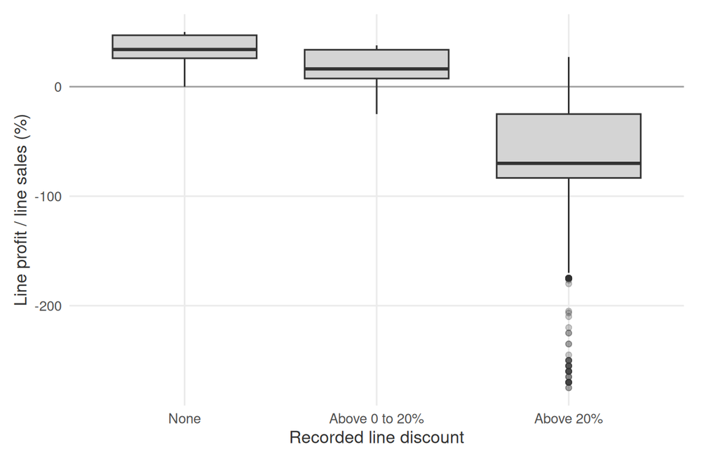

```r
ggplot(lines, aes(discount_band, line_margin_pct)) +
  geom_hline(yintercept = 0, colour = "#A3A3A3") +
  geom_boxplot(fill = petra_accent, outlier.alpha = .25) +
  labs(x = "Recorded line discount", y = "Line profit / line sales (%)")
```

- Compare medians, spread, group sizes and weighted margins.
- The chart gives each line equal weight; the overall margin table does not.
- A negative line margin is possible and is not automatically a bad import.
- Discounts, prices and profit are connected accounting quantities; an association is expected to reflect more than customer response alone.

### Keep product mix visible

```r
within_category <- lines %>% group_by(category, discount_band) %>%
  summarise(line_count = n(), margin_pct = 100 * sum(profit) / sum(sales),
            .groups = "drop")
knitr::kable(within_category, digits = 2)
```

| category | discount_band | line_count | margin_pct |
| --- | --- | --- | --- |
| Furniture | None | 562 | 22.80 |
| Furniture | Above 0 to 20% | 498 | 5.05 |
| Furniture | Above 20% | 375 | -27.45 |
| Office Supplies | None | 2096 | 29.53 |
| Office Supplies | Above 0 to 20% | 1480 | 15.89 |
| Office Supplies | Above 20% | 448 | -115.25 |
| Technology | None | 550 | 33.73 |
| Technology | Above 0 to 20% | 558 | 13.97 |
| Technology | Above 20% | 115 | -23.10 |

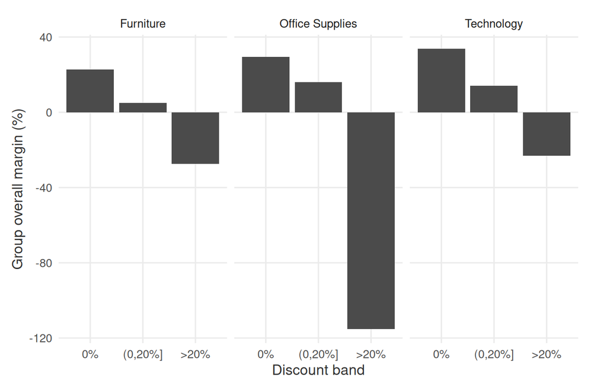

```r
ggplot(within_category, aes(discount_band, margin_pct)) +
  geom_col(fill = petra_ink) + facet_wrap(~ category) +
  scale_x_discrete(labels = c("None" = "0%", "Above 0 to 20%" = "(0,20%]",
                               "Above 20%" = ">20%")) +
  labs(x = "Discount band", y = "Group overall margin (%)")
```

- Stratification compares discount bands within each category.
- It reduces one source of mixing, but does not remove all confounding.
- It does not establish what would happen if the manager changed discounts.

## 5. Association at order level

> Are higher-sales orders also higher-profit orders?

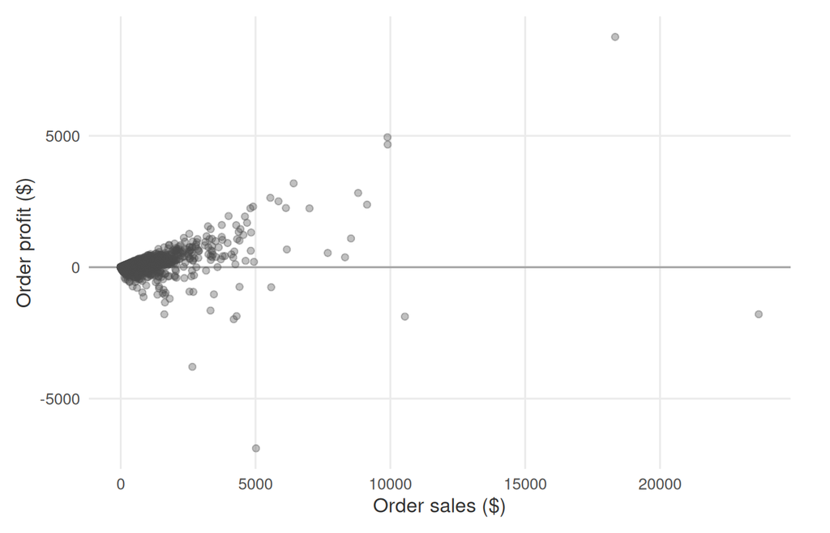

```r
ggplot(orders, aes(sales, profit)) +
  geom_hline(yintercept = 0, colour = "#A3A3A3") +
  geom_point(alpha = .35, colour = petra_ink) +
  labs(x = "Order sales ($)", y = "Order profit ($)")
```

```r
correlations <- orders %>% group_by(segment) %>%
  summarise(orders = n(), pearson_r = cor(sales, profit),
            spearman_r = cor(sales, profit, method = "spearman"), .groups = "drop")
knitr::kable(correlations, digits = 3)
```

| segment | orders | pearson_r | spearman_r |
| --- | --- | --- | --- |
| Consumer | 1710 | 0.364 | 0.495 |
| Corporate | 1021 | 0.757 | 0.505 |
| Home Office | 591 | 0.221 | 0.576 |

- Pearson measures linear association; Spearman uses ranks.
- Large observations can strongly influence Pearson correlation.
- Segment correlations can differ from the overall correlation.
- Correlation does not show the distribution of losses or establish a causal effect.
- Repeated customers matter if we later try to model orders as independent future observations.

## 6. Turn a pattern into a decision question

**Supported wording:**

- “In this extract, the highest discount band has weaker recorded profitability.”
- “Furniture’s overall margin warrants a closer subcategory review.”

**Before proposing a discount change, obtain:**

- Product cost and accounting definitions.
- Promotion timing and reasons for discount assignment.
- Comparable product groups and customer demand evidence.
- A planned experiment or another defensible causal design.
- Do not claim that removing discounts would reproduce the undiscounted group’s margin.
- Do not describe a line-count loss rate as the percentage of customers losing money.

## 7. Independent commercial briefing

1. Rank subcategories by total profit and by overall margin. Include sales and line counts.
2. Select one weak-performing subcategory and compare its discount bands.
3. Find its three largest loss-making lines; retain them in the main analysis.
4. Compare order-level loss percentages across customer segments.
5. Produce two charts answering different questions.
6. Write a recommendation separating an observed finding, a plausible explanation and evidence still needed.

```r
# Use lines for product/discount questions and orders for basket questions.
# A group loss percentage is 100 * mean(profit < 0).
# Calculate rates before overwriting any column with a group total.
```

**Submission:**

- One compact results table.
- Two labelled charts with units and denominators.
- Five short briefing bullets, including one limitation and one proposed follow-up.

## 8. Move from description to inference

- Part 4 covers estimation, hypothesis testing and regression; Part 3 provides the probability foundations.
- The descriptive evidence here concerns the complete fixed extract; p-values are not required to describe its totals.
- `data/business/README.md`.